# Atividade 4

Nayra Bento Côgo

2025-05-15

# Atividade 3

O **objetivo** da atividade é conseguirmos acessar um repositório de dados de ocorrência de espécies, inspecionar os dados, avaliar sua qualidade e fazer um mapa com as ocorrências.

Para isso deveríamos escolher um repositório e uma espécie de interesse.

O repositório escolhido foi o GBIF (Global Biodiversity Information Facility) em conjunto com o OBIS (Ocean Biodiversity Information System), uma vez que a espécie escolhida é marinha : *Callichirus major*

## Repositório GBIF

#### 1 Para alcançarmos o objetivo da atividade começamos instalando os pacotes “tidyverse” e “rgbif”

```r
#instalando os pacotes
library ("tidyverse")
library ("rgbif")
library("dplyr")
```

#### 1.1 Utilizando a função “occ_data” fizemos uma busca simplificada das ocorrências no repositório do GBIF por meio do nome científico, número de identificação, país e outros. Com o foco na espécie escolhida aproveitamos também para selecionar apenas ocorrências que possuem coordenadas e sem problemas geoespaciais.

```r
# checando as funcoes
occ_data
```

[output not shown]

[output cut: 96 more lines]

[output not shown]

```r
# baixando as ocorrencias
corrupto_gbif <- occ_data(scientificName = "Callichirus major",
                      hasCoordinate = TRUE,
                      hasGeospatialIssue=FALSE)

# dimensoes
dim(corrupto_gbif)
```

#### 2 Verificamos o tamanho da tabela de dados (quantas observações e varíaveis).

```r
dim(corrupto_gbif$data)
```

```
## [1] 110 139
```

#### 2.1 Entendendo a estrutura dos dados.

```r
# checar campos
corrupto_gbif$data %>% names
```

```
##   [1] "key"
##   [2] "scientificName"
##   [3] "decimalLatitude"
##   [4] "decimalLongitude"
##   [5] "issues"
##   [6] "datasetKey"
##   [7] "publishingOrgKey"
##   [8] "installationKey"
##   [9] "hostingOrganizationKey"
##  [10] "publishingCountry"
##  [11] "protocol"
##  [12] "lastCrawled"
##  [13] "lastParsed"
##  [14] "crawlId"
##  [15] "basisOfRecord"
```

[output cut: 124 more lines]

#### 2.1.1 Utilizamos a coluna issues pois ela indica problema já identificados pelo validador automático do repositório. Para conferir esse problemas utilizamos a função “gbif_issues”.

```r
gbif_issues()
```

```
##           code                                             issue
## 1          bri                           BASIS_OF_RECORD_INVALID
## 2          ccm                        CONTINENT_COUNTRY_MISMATCH
## 3          cdc                CONTINENT_DERIVED_FROM_COORDINATES
## 4        conti                                 CONTINENT_INVALID
## 5         cdiv                                COORDINATE_INVALID
## 6        cdout                           COORDINATE_OUT_OF_RANGE
## 7        cdrep                            COORDINATE_REPROJECTED
## 8       cdrepf                    COORDINATE_REPROJECTION_FAILED
## 9       cdreps                COORDINATE_REPROJECTION_SUSPICIOUS
## 10     cdround                                COORDINATE_ROUNDED
## 11     cucdmis                       COUNTRY_COORDINATE_MISMATCH
## 12        cudc                  COUNTRY_DERIVED_FROM_COORDINATES
## 13        cuiv                                   COUNTRY_INVALID
## 14         cum                                  COUNTRY_MISMATCH
```

[output cut: 285 more lines]

#### 2.1.2 Nessa etapa checamos os problema reportados e fazemos um pequeno tratamento utilizando a a função “strsplit” para individualizar os issues e conferi-lós.

```r
# checando os problemas reportados
issues_gbif <- corrupto_gbif$data$issues %>%
  unique() %>%
  strsplit(., "[,]") %>%
  unlist()

gbif_issues() %>%
  data.frame() %>%
  filter(code %in% issues_gbif)
```

```
##       code                                            issue
## 1      cdc               CONTINENT_DERIVED_FROM_COORDINATES
## 2    conti                                CONTINENT_INVALID
## 3  cdround                               COORDINATE_ROUNDED
## 4     cudc                 COUNTRY_DERIVED_FROM_COORDINATES
## 5     cuiv                                  COUNTRY_INVALID
## 6   gass84                     GEODETIC_DATUM_ASSUMED_WGS84
## 7    osiic OCCURRENCE_STATUS_INFERRED_FROM_INDIVIDUAL_COUNT
## 8  colmafu                           COLLECTION_MATCH_FUZZY
## 9  colmano                            COLLECTION_MATCH_NONE
## 10 incomis                  INSTITUTION_COLLECTION_MISMATCH
## 11  inmafu                          INSTITUTION_MATCH_FUZZY
## 12  inmano                           INSTITUTION_MATCH_NONE
## 13 diffown                      DIFFERENT_OWNER_INSTITUTION
##                                                                                                                                                              description
```

[output cut: 27 more lines]

#### 2.2 Seguimos selecionando algumas varíaveis para a validação dos dados e futuras análises, como coordenadas, profundidade, nome da base de dados etc.

```r
corrupto_gbif1 <-  corrupto_gbif$data %>%
  dplyr::select(scientificName, acceptedScientificName, decimalLatitude, decimalLongitude,
                issues, waterBody, basisOfRecord, occurrenceStatus, rightsHolder,
                datasetName, recordedBy, depth, locality, habitat)
```

#### 2.3 Analisamos quantas ocorrências foram únicas aplicando a função “distinct” do pacote dplyr.

```r
corrupto_gbif1 <- corrupto_gbif1 %>%
  distinct()
```

#### 2.4 Aplicamos a função unique a cada coluna com um loop na função “lapply” para identificar todos os valores únicos presentes nos dados.

```r
# checando os niveis dos fatores
lapply(corrupto_gbif1, unique)
```

```
## $scientificName
## [1] "Callichirus major (Say, 1818)" "Callianassa major Say, 1818"
##
## $acceptedScientificName
## [1] "Callichirus major (Say, 1818)"
##
## $decimalLatitude
##  [1]  31.24847  32.76169  33.86552  31.42966  32.58446  32.31455  32.37589
##  [8]  33.51456  31.14545  32.12659  32.35273  32.37306  33.85137  32.12392
## [15]  32.12391  32.19226  32.19226  32.19680  31.13542  33.86470  32.37470
## [22]  31.21432  33.42195  32.57133  32.13698  32.49339  31.03932  32.59855
## [29]  32.79861  32.20020  27.46517  29.71030  29.66244  32.59266  29.17828
## [36]  32.64150  29.33333  29.50000 -19.95911  32.17083 -23.99846  31.69543
## [43]  26.77830  27.47000  27.88000 -24.02044  27.47170  27.46330 -23.96922
## [50]  27.46170 -23.93000  32.69167  27.18170  33.82740  27.86000  27.17500
```

[output cut: 225 more lines]

#### 2.5 Para refirnarmos os nossos dados precisamos conferir se as coordenadas são válidas utilizando funções dos pacotes “CoordinateCleaner” e “bcd”

```r
library(bdc)
library(CoordinateCleaner)

# checando as coordenadas válidas e próximas a capitais (muitas vezes as coordenadas são erroneamente associadas a capitais dos países)

cl <- corrupto_gbif1 %>%
  CoordinateCleaner::clean_coordinates(species = "acceptedScientificName",
                                       lat = "decimalLatitude",
                                       lon = "decimalLongitude",
                                       tests = c("capitals",
                                                 "centroids","equal",
                                                 "gbif", "institutions",
                                                 "outliers", "seas",
                                                 "zeros"))
```

```
## Testing coordinate validity
```

```
## Flagged 0 records.
```

```
## Testing equal lat/lon
```

```
## Flagged 0 records.
```

```
## Testing zero coordinates
```

```
## Flagged 0 records.
```

```
## Testing country capitals
```

```
## Flagged 0 records.
```

```
## Testing country centroids
```

```
## Flagged 0 records.
```

```
## Testing sea coordinates
```

```
## Flagged 72 records.
```

```
## Testing geographic outliers
```

```
## Flagged 9 records.
```

```
## Testing GBIF headquarters, flagging records around Copenhagen
```

```
## Flagged 0 records.
```

```
## Testing biodiversity institutions
```

```
## Flagged 0 records.
```

```
## Flagged 76 of 88 records, EQ = 0.86.
```

#### 2.5.1 Como algumas coordenadas podem estar em terra e estamos trabalhando com um animal de ambiente praial, esperamos que ele seja encontrado mais próximo a costa. Por isso, conferimos se não há coordenadas em terra muito discrepantes localizadas em terras firmes. Visualizamos as coordenadas por meio de um mapa usando o pacote “ggplot2”.

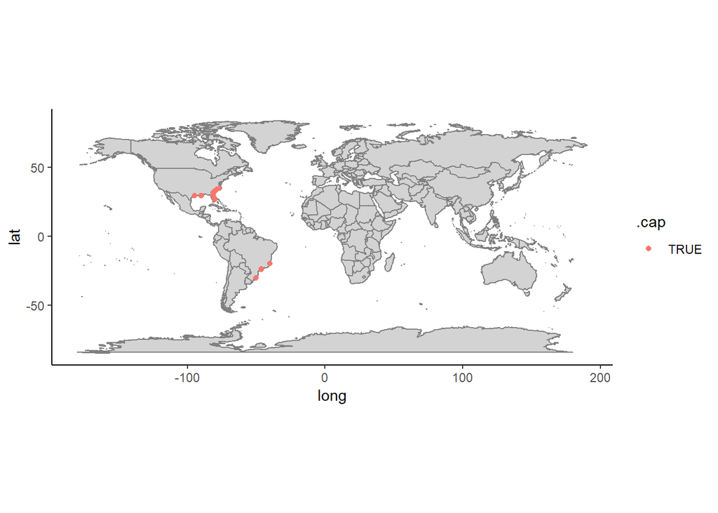

```r
# verificando as coordenadas com flags
library(ggplot2)

# capitais (padrão é um raio de 10km)
ggplot() +
  borders("world", fill = "lightgray") +
  geom_point(data = cl, aes(x = decimalLongitude, y = decimalLatitude, color = `.cap`)) +
  coord_quickmap() +
  theme_classic()
```

#### 2.6 Nessa etapa verificamos se se os pontos de ocorrência estão corretamente localizados no mar, de acordo com a variável .sea

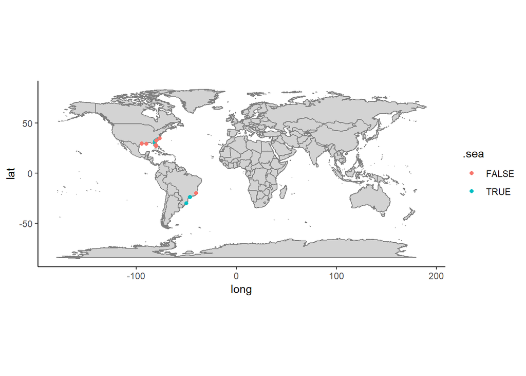

```r
# pontos no mar
ggplot() +
  borders("world", fill = "lightgray") +
  geom_point(data = cl, aes(x = decimalLongitude, y = decimalLatitude, color = `.sea`)) +
  coord_quickmap() +
  theme_classic()
```

#### 3 Fizemos uma limpeza dos nossos dados já que, usamos registros do GBIF e algum dado poderia demonstrar uma certa discrepância.

```r
# filtrando todas do dataset suspeito
corrupto_gbif_noDiveboard <- corrupto_gbif1 %>%
  filter(!datasetName %in% c("Diveboard - Scuba diving citizen science"))
```

#### 3.1 Seguimos limpando os dado mais ao norte.

```r
corrupto_gbif_noDiveboard %>%
  filter(decimalLatitude > 25) %>%
  arrange(-decimalLatitude) %>%
  data.frame()
```

```
##                   scientificName        acceptedScientificName decimalLatitude
## 1  Callichirus major (Say, 1818) Callichirus major (Say, 1818)        34.72000
## 2  Callichirus major (Say, 1818) Callichirus major (Say, 1818)        34.69680
## 3  Callichirus major (Say, 1818) Callichirus major (Say, 1818)        33.86552
## 4  Callichirus major (Say, 1818) Callichirus major (Say, 1818)        33.86470
## 5  Callichirus major (Say, 1818) Callichirus major (Say, 1818)        33.85137
## 6  Callichirus major (Say, 1818) Callichirus major (Say, 1818)        33.82740
## 7  Callichirus major (Say, 1818) Callichirus major (Say, 1818)        33.51456
## 8  Callichirus major (Say, 1818) Callichirus major (Say, 1818)        33.43322
## 9  Callichirus major (Say, 1818) Callichirus major (Say, 1818)        33.42195
## 10 Callichirus major (Say, 1818) Callichirus major (Say, 1818)        32.79861
## 11 Callichirus major (Say, 1818) Callichirus major (Say, 1818)        32.76518
## 12 Callichirus major (Say, 1818) Callichirus major (Say, 1818)        32.76518
## 13 Callichirus major (Say, 1818) Callichirus major (Say, 1818)        32.76169
## 14 Callichirus major (Say, 1818) Callichirus major (Say, 1818)        32.69167
```

[output cut: 649 more lines]

#### 3.1.1 Mantemos os registros de latitude menor que 31 graus.

```r
corrupto_gbif_ok <- corrupto_gbif_noDiveboard %>%
  filter(decimalLatitude < 31)
```

#### 4 Checamos os nosso pontos através do mapa mundi por meio das coordenadas. Para isso carregamos as nossas bibliotecas “ggmap”, “maps” e “mapdata”

```r
library(ggmap)
```

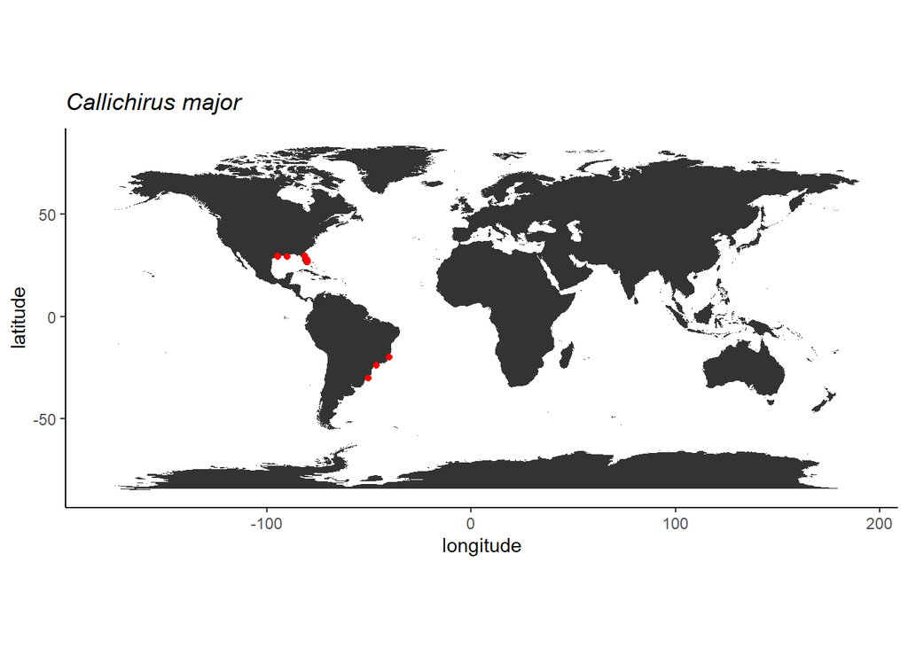

```r
library(maps)
library(mapdata)

world <- map_data('world')

# checando os pontos

ggplot() +
  geom_polygon(data = world, aes(x = long, y = lat, group = group)) +
  coord_fixed() +
  theme_classic() +
  geom_point(data = corrupto_gbif_ok, aes(x = decimalLongitude, y = decimalLatitude), color = "red") +
  labs(x = "longitude", y = "latitude", title = expression(italic("Callichirus major")))
```

## Repositório OBIS

### Para o repositório do OBIS seguimos com os mesmos procedimentos que utilizamos no GBIF

#### 1 Utilizamos o pacote “robis” e a função occurrence deste pacote.

```r
## OBIS
corrupto_obis <- robis::occurrence("Callichirus major")
```

```
## Retrieved 58 records of approximately 58 (100%)
```

#### 1.1 As variavéis tem os mesmo nomes, já que tanto o OBIS quanto o GBIF utilizam o sistema DwC, mas os problemas reportados neste caso são indicados na coluna flags.

```r
# checando os dados
names(corrupto_obis)
```

```
##  [1] "basisOfRecord"            "brackish"
##  [3] "catalogNumber"            "class"
##  [5] "classid"                  "collectionCode"
##  [7] "country"                  "county"
##  [9] "decimalLatitude"          "decimalLongitude"
## [11] "family"                   "familyid"
## [13] "fieldNumber"              "genus"
## [15] "genusid"                  "infraorder"
## [17] "infraorderid"             "institutionCode"
## [19] "kingdom"                  "kingdomid"
## [21] "locality"                 "marine"
## [23] "order"                    "orderid"
## [25] "phylum"                   "phylumid"
## [27] "scientificName"           "scientificNameAuthorship"
## [29] "scientificNameID"         "species"
```

[output cut: 33 more lines]

#### 1.2 Filtramos os dados de ocorrências da espécies do trabalho e identificamos registros potencialmente problemáticos.

```r
corrupto_obis1 <- corrupto_obis %>%
  dplyr::select(scientificName, decimalLatitude, decimalLongitude, bathymetry,
                flags, waterBody, basisOfRecord, occurrenceStatus,
                datasetName, recordedBy, depth, locality) %>%
  distinct()

# check problemas reportados (flags)
corrupto_obis1 %>%
  distinct(flags)
```

```
## # A tibble: 4 × 1
##   flags
##   <chr>
## 1 NO_DEPTH,ON_LAND
## 2 NO_DEPTH
## 3 ON_LAND
## 4 <NA>
```

#### 1.3 Nessa etapa usamos as flags para fitrar as ocorrências em terra.

```r
# check NA em datasetName
corrupto_obis1 %>%
  filter(!flags %in% c("NO_DEPTH,ON_LAND", "ON_LAND", "DEPTH_EXCEEDS_BATH,ON_LAND"),
         is.na(datasetName)) %>%
  distinct(waterBody)
```

```
## # A tibble: 4 × 1
##   waterBody
##   <chr>
## 1 North Atlantic Ocean
## 2 <NA>
## 3 South Atlantic
## 4 Gulf of Mexico
```

#### 1.4 Verificamos se aida há ocorrências estranhas.

```r
# checando os niveis
corrupto_obis1 %>%
  filter(!flags %in% c("NO_DEPTH,ON_LAND", "ON_LAND", "DEPTH_EXCEEDS_BATH,ON_LAND"),
         !is.na(datasetName),
         !waterBody %in% c("North Atlantic Ocean", "South Atlantic", "Gulf of Mexico")) %>%
  lapply(., unique)
```

```
## $scientificName
## character(0)
##
## $decimalLatitude
## numeric(0)
##
## $decimalLongitude
## numeric(0)
##
## $bathymetry
## integer(0)
##
## $flags
## character(0)
##
## $waterBody
## character(0)
##
## $basisOfRecord
## character(0)
##
## $occurrenceStatus
## character(0)
##
## $datasetName
## character(0)
##
## $recordedBy
## character(0)
##
## $depth
## numeric(0)
##
## $locality
## character(0)
```

#### 1.6 Filtramos as ocorrências mais confiáveis e plotei esses dados em um mapa. Como não tivemos ocorrências no OBIS, não identificamos elas no mapa.

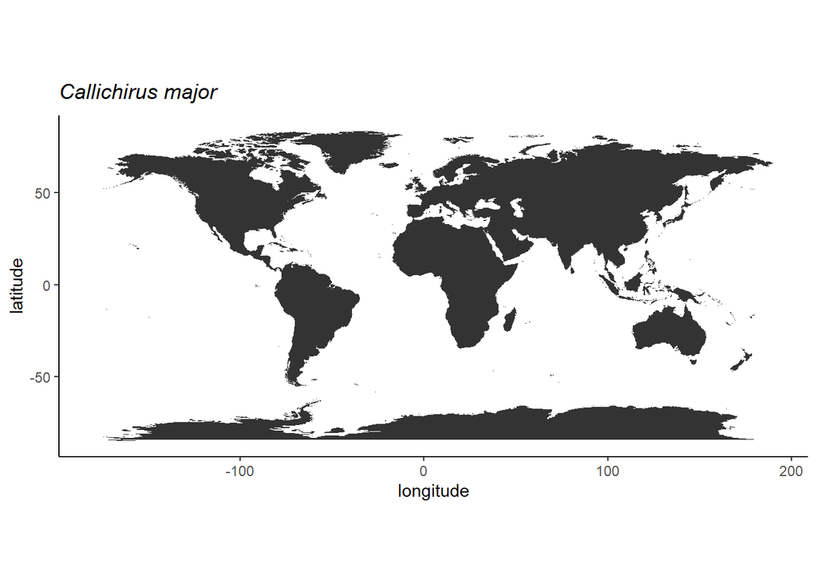

```r
# aplicando os filtros
corrupto_obis_ok <- corrupto_obis1 %>%
  filter(!flags %in% c("NO_DEPTH,ON_LAND", "ON_LAND", "DEPTH_EXCEEDS_BATH,ON_LAND"),
         !is.na(datasetName),
         !waterBody %in% c("North Atlantic Ocean", "South Atlantic", "Gulf of Mexico"))

# plot
ggplot() +
  geom_polygon(data = world, aes(x = long, y = lat, group = group)) +
  coord_fixed() +
  theme_classic() +
  geom_point(data = corrupto_obis_ok, aes(x = decimalLongitude, y = decimalLatitude, color = waterBody)) +
  labs(x = "longitude", y = "latitude", title = expression(italic("Callichirus major")))
```

```r
corrupto_obis_final <- corrupto_obis_ok %>%
  filter(decimalLongitude > 0 | decimalLongitude > -100)
```

## UNINDO OS DADOS DO GBIF E OBIS

#### 1 Vamos comparar as colunas dos dois data frames.

```r
# unindo GBIF e OBIS
# vendo as diferencas
setdiff(names(corrupto_gbif_ok), names(corrupto_obis_ok))
```

```
## [1] "acceptedScientificName" "issues"                 "rightsHolder"
## [4] "habitat"
```

```r
setdiff(names(corrupto_obis_final), names(corrupto_obis_final))
```

```
## character(0)
```

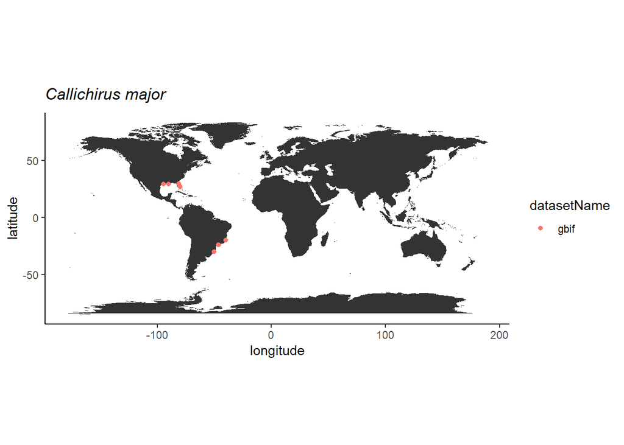

```r
all_data <- bind_rows(corrupto_gbif_ok %>%
                        mutate(repo = paste0("gbif", row.names(.))),
                      corrupto_obis_final %>%
                        mutate(repo = paste0("obis", row.names(.)))) %>%
  column_to_rownames("repo") %>%
  dplyr::select(decimalLongitude, decimalLatitude, depth) %>%
  distinct() %>%
  rownames_to_column("occ") %>%
  separate(col = "occ", into = c("datasetName", "rn"), sep = 4) %>%
  mutate(scientificName = "Callichirus major") %>%
  dplyr::select(-rn)


# mapeando as ocorrencias
ggplot() +
  geom_polygon(data = world, aes(x = long, y = lat, group = group)) +
  coord_fixed() +
  theme_classic() +
  geom_point(data = all_data, aes(x = decimalLongitude, y = decimalLatitude, color = datasetName)) +
  #theme(legend.title = element_blank()) +
  labs(x = "longitude", y = "latitude", title = expression(italic("Callichirus major")))
```

#### Os dados foram guardados.

```r
#salavando os dados em csv
write.csv(all_data, "occ_GBIF-OBIS_par_hepa.csv", row.names = FALSE)
```